# Risk Factor Analysis

## Outcome Variable

**Outcome Variable:** ever_swasted

## Predictor Variables

**Intervention Variable:** nchldlt5

**Adjustment Set:**

unadjusted

## Stratifying Variables

The analysis was stratified on these variable(s):

- agecat
- studyid
- country

## Data Summary

| agecat | studyid | country | nchldlt5 | ever_swasted | n_cell | n |
| --- | --- | --- | --- | --- | --- | --- |
| 0-24 months | iLiNS-Zinc | BURKINA FASO | 1 | 0 | 1032 | 3189 |
| 0-24 months | iLiNS-Zinc | BURKINA FASO | 1 | 1 | 41 | 3189 |
| 0-24 months | iLiNS-Zinc | BURKINA FASO | 2+ | 0 | 2005 | 3189 |
| 0-24 months | iLiNS-Zinc | BURKINA FASO | 2+ | 1 | 111 | 3189 |
| 0-24 months | IRC | INDIA | 1 | 0 | 52 | 410 |
| 0-24 months | IRC | INDIA | 1 | 1 | 37 | 410 |
| 0-24 months | IRC | INDIA | 2+ | 0 | 218 | 410 |
| 0-24 months | IRC | INDIA | 2+ | 1 | 103 | 410 |
| 0-24 months | LCNI-5 | MALAWI | 1 | 0 | 387 | 812 |
| 0-24 months | LCNI-5 | MALAWI | 1 | 1 | 4 | 812 |
| 0-24 months | LCNI-5 | MALAWI | 2+ | 0 | 417 | 812 |
| 0-24 months | LCNI-5 | MALAWI | 2+ | 1 | 4 | 812 |
| 0-24 months | NIH-Crypto | BANGLADESH | 1 | 0 | 491 | 758 |
| 0-24 months | NIH-Crypto | BANGLADESH | 1 | 1 | 50 | 758 |
| 0-24 months | NIH-Crypto | BANGLADESH | 2+ | 0 | 201 | 758 |
| 0-24 months | NIH-Crypto | BANGLADESH | 2+ | 1 | 16 | 758 |
| 0-24 months | PROVIDE | BANGLADESH | 1 | 0 | 481 | 700 |
| 0-24 months | PROVIDE | BANGLADESH | 1 | 1 | 31 | 700 |
| 0-24 months | PROVIDE | BANGLADESH | 2+ | 0 | 177 | 700 |
| 0-24 months | PROVIDE | BANGLADESH | 2+ | 1 | 11 | 700 |
| 0-24 months | TanzaniaChild2 | TANZANIA, UNITED REPUBLIC OF | 1 | 0 | 1525 | 2385 |
| 0-24 months | TanzaniaChild2 | TANZANIA, UNITED REPUBLIC OF | 1 | 1 | 112 | 2385 |
| 0-24 months | TanzaniaChild2 | TANZANIA, UNITED REPUBLIC OF | 2+ | 0 | 703 | 2385 |
| 0-24 months | TanzaniaChild2 | TANZANIA, UNITED REPUBLIC OF | 2+ | 1 | 45 | 2385 |
| 0-6 months | IRC | INDIA | 1 | 0 | 55 | 410 |
| 0-6 months | IRC | INDIA | 1 | 1 | 34 | 410 |
| 0-6 months | IRC | INDIA | 2+ | 0 | 229 | 410 |
| 0-6 months | IRC | INDIA | 2+ | 1 | 92 | 410 |
| 0-6 months | LCNI-5 | MALAWI | 1 | 0 | 122 | 267 |
| 0-6 months | LCNI-5 | MALAWI | 1 | 1 | 0 | 267 |
| 0-6 months | LCNI-5 | MALAWI | 2+ | 0 | 145 | 267 |
| 0-6 months | LCNI-5 | MALAWI | 2+ | 1 | 0 | 267 |
| 0-6 months | NIH-Crypto | BANGLADESH | 1 | 0 | 502 | 758 |
| 0-6 months | NIH-Crypto | BANGLADESH | 1 | 1 | 39 | 758 |
| 0-6 months | NIH-Crypto | BANGLADESH | 2+ | 0 | 206 | 758 |
| 0-6 months | NIH-Crypto | BANGLADESH | 2+ | 1 | 11 | 758 |
| 0-6 months | PROVIDE | BANGLADESH | 1 | 0 | 488 | 700 |
| 0-6 months | PROVIDE | BANGLADESH | 1 | 1 | 24 | 700 |
| 0-6 months | PROVIDE | BANGLADESH | 2+ | 0 | 183 | 700 |
| 0-6 months | PROVIDE | BANGLADESH | 2+ | 1 | 5 | 700 |
| 0-6 months | TanzaniaChild2 | TANZANIA, UNITED REPUBLIC OF | 1 | 0 | 1580 | 2385 |
| 0-6 months | TanzaniaChild2 | TANZANIA, UNITED REPUBLIC OF | 1 | 1 | 57 | 2385 |
| 0-6 months | TanzaniaChild2 | TANZANIA, UNITED REPUBLIC OF | 2+ | 0 | 727 | 2385 |
| 0-6 months | TanzaniaChild2 | TANZANIA, UNITED REPUBLIC OF | 2+ | 1 | 21 | 2385 |
| 6-24 months | iLiNS-Zinc | BURKINA FASO | 1 | 0 | 1032 | 3189 |
| 6-24 months | iLiNS-Zinc | BURKINA FASO | 1 | 1 | 41 | 3189 |
| 6-24 months | iLiNS-Zinc | BURKINA FASO | 2+ | 0 | 2005 | 3189 |
| 6-24 months | iLiNS-Zinc | BURKINA FASO | 2+ | 1 | 111 | 3189 |
| 6-24 months | IRC | INDIA | 1 | 0 | 83 | 410 |
| 6-24 months | IRC | INDIA | 1 | 1 | 6 | 410 |
| 6-24 months | IRC | INDIA | 2+ | 0 | 301 | 410 |
| 6-24 months | IRC | INDIA | 2+ | 1 | 20 | 410 |
| 6-24 months | LCNI-5 | MALAWI | 1 | 0 | 380 | 800 |
| 6-24 months | LCNI-5 | MALAWI | 1 | 1 | 4 | 800 |
| 6-24 months | LCNI-5 | MALAWI | 2+ | 0 | 412 | 800 |
| 6-24 months | LCNI-5 | MALAWI | 2+ | 1 | 4 | 800 |
| 6-24 months | NIH-Crypto | BANGLADESH | 1 | 0 | 505 | 730 |
| 6-24 months | NIH-Crypto | BANGLADESH | 1 | 1 | 15 | 730 |
| 6-24 months | NIH-Crypto | BANGLADESH | 2+ | 0 | 205 | 730 |
| 6-24 months | NIH-Crypto | BANGLADESH | 2+ | 1 | 5 | 730 |
| 6-24 months | PROVIDE | BANGLADESH | 1 | 0 | 441 | 615 |
| 6-24 months | PROVIDE | BANGLADESH | 1 | 1 | 7 | 615 |
| 6-24 months | PROVIDE | BANGLADESH | 2+ | 0 | 161 | 615 |
| 6-24 months | PROVIDE | BANGLADESH | 2+ | 1 | 6 | 615 |
| 6-24 months | TanzaniaChild2 | TANZANIA, UNITED REPUBLIC OF | 1 | 0 | 1324 | 2010 |
| 6-24 months | TanzaniaChild2 | TANZANIA, UNITED REPUBLIC OF | 1 | 1 | 59 | 2010 |
| 6-24 months | TanzaniaChild2 | TANZANIA, UNITED REPUBLIC OF | 2+ | 0 | 603 | 2010 |
| 6-24 months | TanzaniaChild2 | TANZANIA, UNITED REPUBLIC OF | 2+ | 1 | 24 | 2010 |

The following strata were considered:

- agecat: 0-24 months, studyid: iLiNS-Zinc, country: BURKINA FASO
- agecat: 0-24 months, studyid: IRC, country: INDIA
- agecat: 0-24 months, studyid: LCNI-5, country: MALAWI
- agecat: 0-24 months, studyid: NIH-Crypto, country: BANGLADESH
- agecat: 0-24 months, studyid: PROVIDE, country: BANGLADESH
- agecat: 0-24 months, studyid: TanzaniaChild2, country: TANZANIA, UNITED REPUBLIC OF
- agecat: 0-6 months, studyid: IRC, country: INDIA
- agecat: 0-6 months, studyid: LCNI-5, country: MALAWI
- agecat: 0-6 months, studyid: NIH-Crypto, country: BANGLADESH
- agecat: 0-6 months, studyid: PROVIDE, country: BANGLADESH
- agecat: 0-6 months, studyid: TanzaniaChild2, country: TANZANIA, UNITED REPUBLIC OF
- agecat: 6-24 months, studyid: iLiNS-Zinc, country: BURKINA FASO
- agecat: 6-24 months, studyid: IRC, country: INDIA
- agecat: 6-24 months, studyid: LCNI-5, country: MALAWI
- agecat: 6-24 months, studyid: NIH-Crypto, country: BANGLADESH
- agecat: 6-24 months, studyid: PROVIDE, country: BANGLADESH
- agecat: 6-24 months, studyid: TanzaniaChild2, country: TANZANIA, UNITED REPUBLIC OF

### Dropped Strata

Some strata were dropped due to rare outcomes:

- agecat: 0-24 months, studyid: LCNI-5, country: MALAWI
- agecat: 0-6 months, studyid: LCNI-5, country: MALAWI
- agecat: 6-24 months, studyid: LCNI-5, country: MALAWI

## Methods Detail

We’re interested in the causal parameters $E[Y_a]$ for all values of $a \in \mathcal{A}$. These parameters represent the mean outcome if, possibly contrary to fact, we intervened to set all units to have $A=a$. Under the randomization and positivity assumptions, these are identified by the statistical parameters $\psi_a=E_W[E_{Y|A,W}(Y|A=a,W)]$. In addition, we’re interested in the mean of $Y$, $E[Y]$ under no intervention (the observed mean). We will estimate these parameters by using SuperLearner to fit the relevant likelihood factors – $E_{Y|A,W}(Y|A=a,W)$ and $p(A=a|W)$, and then updating our likelihood fit using a joint TMLE.

For unadjusted analyses ($W=\{\}$), initial likelihoods were estimated using Lrnr_glm to estimate the simple $E(Y|A)$ and Lrnr_mean to estimate $p(A)$. For adjusted analyses, a small library containing Lrnr_glmnet, Lrnr_xgboost, and Lrnr_mean was used.

Having estimated these parameters, we will then use the delta method to estimate relative risks and attributable risks relative to a prespecified baseline level of $A$.

# Results Detail

## Results Plots

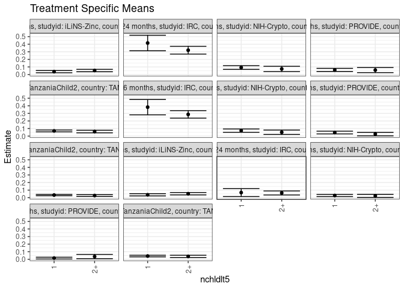

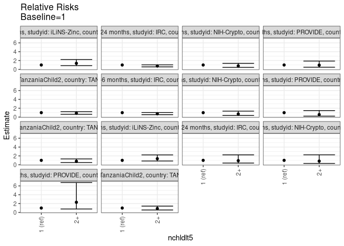

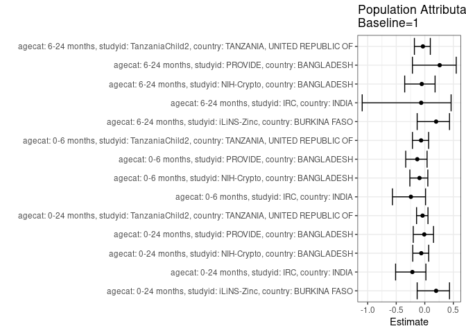

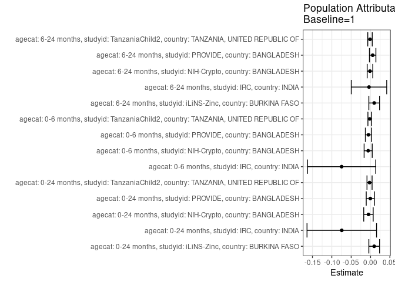

## Results Table

### Parameter: TSM

| agecat | studyid | country | intervention_level | baseline_level | estimate | ci_lower | ci_upper |
| --- | --- | --- | --- | --- | --- | --- | --- |
| 0-24 months | iLiNS-Zinc | BURKINA FASO | 1 | NA | 0.0382106 | 0.0233347 | 0.0530865 |
| 0-24 months | iLiNS-Zinc | BURKINA FASO | 2+ | NA | 0.0524575 | 0.0367958 | 0.0681191 |
| 0-24 months | IRC | INDIA | 1 | NA | 0.4157303 | 0.3132133 | 0.5182473 |
| 0-24 months | IRC | INDIA | 2+ | NA | 0.3208723 | 0.2697432 | 0.3720013 |
| 0-24 months | NIH-Crypto | BANGLADESH | 1 | NA | 0.0924214 | 0.0680004 | 0.1168425 |
| 0-24 months | NIH-Crypto | BANGLADESH | 2+ | NA | 0.0737327 | 0.0389388 | 0.1085266 |
| 0-24 months | PROVIDE | BANGLADESH | 1 | NA | 0.0605469 | 0.0398737 | 0.0812200 |
| 0-24 months | PROVIDE | BANGLADESH | 2+ | NA | 0.0585106 | 0.0249365 | 0.0920848 |
| 0-24 months | TanzaniaChild2 | TANZANIA, UNITED REPUBLIC OF | 1 | NA | 0.0684178 | 0.0561855 | 0.0806502 |
| 0-24 months | TanzaniaChild2 | TANZANIA, UNITED REPUBLIC OF | 2+ | NA | 0.0601604 | 0.0431165 | 0.0772044 |
| 0-6 months | IRC | INDIA | 1 | NA | 0.3820225 | 0.2809544 | 0.4830906 |
| 0-6 months | IRC | INDIA | 2+ | NA | 0.2866044 | 0.2370785 | 0.3361303 |
| 0-6 months | NIH-Crypto | BANGLADESH | 1 | NA | 0.0720887 | 0.0502804 | 0.0938971 |
| 0-6 months | NIH-Crypto | BANGLADESH | 2+ | NA | 0.0506912 | 0.0214850 | 0.0798974 |
| 0-6 months | PROVIDE | BANGLADESH | 1 | NA | 0.0468750 | 0.0285532 | 0.0651968 |
| 0-6 months | PROVIDE | BANGLADESH | 2+ | NA | 0.0265957 | 0.0035796 | 0.0496119 |
| 0-6 months | TanzaniaChild2 | TANZANIA, UNITED REPUBLIC OF | 1 | NA | 0.0348198 | 0.0259374 | 0.0437022 |
| 0-6 months | TanzaniaChild2 | TANZANIA, UNITED REPUBLIC OF | 2+ | NA | 0.0280749 | 0.0162345 | 0.0399152 |
| 6-24 months | iLiNS-Zinc | BURKINA FASO | 1 | NA | 0.0382106 | 0.0233347 | 0.0530865 |
| 6-24 months | iLiNS-Zinc | BURKINA FASO | 2+ | NA | 0.0524575 | 0.0367958 | 0.0681191 |
| 6-24 months | IRC | INDIA | 1 | NA | 0.0674157 | 0.0152593 | 0.1195722 |
| 6-24 months | IRC | INDIA | 2+ | NA | 0.0623053 | 0.0358313 | 0.0887793 |
| 6-24 months | NIH-Crypto | BANGLADESH | 1 | NA | 0.0288462 | 0.0144505 | 0.0432418 |
| 6-24 months | NIH-Crypto | BANGLADESH | 2+ | NA | 0.0238095 | 0.0031757 | 0.0444433 |
| 6-24 months | PROVIDE | BANGLADESH | 1 | NA | 0.0156250 | 0.0041315 | 0.0271185 |
| 6-24 months | PROVIDE | BANGLADESH | 2+ | NA | 0.0359281 | 0.0076783 | 0.0641779 |
| 6-24 months | TanzaniaChild2 | TANZANIA, UNITED REPUBLIC OF | 1 | NA | 0.0426609 | 0.0320074 | 0.0533144 |
| 6-24 months | TanzaniaChild2 | TANZANIA, UNITED REPUBLIC OF | 2+ | NA | 0.0382775 | 0.0232558 | 0.0532992 |

### Parameter: E(Y)

| agecat | studyid | country | intervention_level | baseline_level | estimate | ci_lower | ci_upper |
| --- | --- | --- | --- | --- | --- | --- | --- |
| 0-24 months | iLiNS-Zinc | BURKINA FASO | NA | NA | 0.0476638 | 0.0358801 | 0.0594476 |
| 0-24 months | IRC | INDIA | NA | NA | 0.3414634 | 0.2955068 | 0.3874201 |
| 0-24 months | NIH-Crypto | BANGLADESH | NA | NA | 0.0870712 | 0.0669870 | 0.1071555 |
| 0-24 months | PROVIDE | BANGLADESH | NA | NA | 0.0600000 | 0.0423945 | 0.0776055 |
| 0-24 months | TanzaniaChild2 | TANZANIA, UNITED REPUBLIC OF | NA | NA | 0.0658281 | 0.0558737 | 0.0757825 |
| 0-6 months | IRC | INDIA | NA | NA | 0.3073171 | 0.2626027 | 0.3520314 |
| 0-6 months | NIH-Crypto | BANGLADESH | NA | NA | 0.0659631 | 0.0482810 | 0.0836451 |
| 0-6 months | PROVIDE | BANGLADESH | NA | NA | 0.0414286 | 0.0266555 | 0.0562017 |
| 0-6 months | TanzaniaChild2 | TANZANIA, UNITED REPUBLIC OF | NA | NA | 0.0327044 | 0.0255647 | 0.0398441 |
| 6-24 months | iLiNS-Zinc | BURKINA FASO | NA | NA | 0.0476638 | 0.0358801 | 0.0594476 |
| 6-24 months | IRC | INDIA | NA | NA | 0.0634146 | 0.0397960 | 0.0870333 |
| 6-24 months | NIH-Crypto | BANGLADESH | NA | NA | 0.0273973 | 0.0155476 | 0.0392469 |
| 6-24 months | PROVIDE | BANGLADESH | NA | NA | 0.0211382 | 0.0097604 | 0.0325160 |
| 6-24 months | TanzaniaChild2 | TANZANIA, UNITED REPUBLIC OF | NA | NA | 0.0412935 | 0.0325931 | 0.0499940 |

### Parameter: RR

| agecat | studyid | country | intervention_level | baseline_level | estimate | ci_lower | ci_upper |
| --- | --- | --- | --- | --- | --- | --- | --- |
| 0-24 months | iLiNS-Zinc | BURKINA FASO | 1 | 1 | 1.0000000 | 1.0000000 | 1.000000 |
| 0-24 months | iLiNS-Zinc | BURKINA FASO | 2+ | 1 | 1.3728503 | 0.8471436 | 2.224792 |
| 0-24 months | IRC | INDIA | 1 | 1 | 1.0000000 | 1.0000000 | 1.000000 |
| 0-24 months | IRC | INDIA | 2+ | 1 | 0.7718279 | 0.5754567 | 1.035210 |
| 0-24 months | NIH-Crypto | BANGLADESH | 1 | 1 | 1.0000000 | 1.0000000 | 1.000000 |
| 0-24 months | NIH-Crypto | BANGLADESH | 2+ | 1 | 0.7977880 | 0.4645213 | 1.370154 |
| 0-24 months | PROVIDE | BANGLADESH | 1 | 1 | 1.0000000 | 1.0000000 | 1.000000 |
| 0-24 months | PROVIDE | BANGLADESH | 2+ | 1 | 0.9663693 | 0.4956310 | 1.884203 |
| 0-24 months | TanzaniaChild2 | TANZANIA, UNITED REPUBLIC OF | 1 | 1 | 1.0000000 | 1.0000000 | 1.000000 |
| 0-24 months | TanzaniaChild2 | TANZANIA, UNITED REPUBLIC OF | 2+ | 1 | 0.8793091 | 0.6289993 | 1.229229 |
| 0-6 months | IRC | INDIA | 1 | 1 | 1.0000000 | 1.0000000 | 1.000000 |
| 0-6 months | IRC | INDIA | 2+ | 1 | 0.7502291 | 0.5469642 | 1.029032 |
| 0-6 months | NIH-Crypto | BANGLADESH | 1 | 1 | 1.0000000 | 1.0000000 | 1.000000 |
| 0-6 months | NIH-Crypto | BANGLADESH | 2+ | 1 | 0.7031785 | 0.3668155 | 1.347980 |
| 0-6 months | PROVIDE | BANGLADESH | 1 | 1 | 1.0000000 | 1.0000000 | 1.000000 |
| 0-6 months | PROVIDE | BANGLADESH | 2+ | 1 | 0.5673759 | 0.2195194 | 1.466455 |
| 0-6 months | TanzaniaChild2 | TANZANIA, UNITED REPUBLIC OF | 1 | 1 | 1.0000000 | 1.0000000 | 1.000000 |
| 0-6 months | TanzaniaChild2 | TANZANIA, UNITED REPUBLIC OF | 2+ | 1 | 0.8062905 | 0.4925295 | 1.319930 |
| 6-24 months | iLiNS-Zinc | BURKINA FASO | 1 | 1 | 1.0000000 | 1.0000000 | 1.000000 |
| 6-24 months | iLiNS-Zinc | BURKINA FASO | 2+ | 1 | 1.3728503 | 0.8471436 | 2.224792 |
| 6-24 months | IRC | INDIA | 1 | 1 | 1.0000000 | 1.0000000 | 1.000000 |
| 6-24 months | IRC | INDIA | 2+ | 1 | 0.9241952 | 0.3823225 | 2.234074 |
| 6-24 months | NIH-Crypto | BANGLADESH | 1 | 1 | 1.0000000 | 1.0000000 | 1.000000 |
| 6-24 months | NIH-Crypto | BANGLADESH | 2+ | 1 | 0.8253968 | 0.3036345 | 2.243750 |
| 6-24 months | PROVIDE | BANGLADESH | 1 | 1 | 1.0000000 | 1.0000000 | 1.000000 |
| 6-24 months | PROVIDE | BANGLADESH | 2+ | 1 | 2.2994012 | 0.7834301 | 6.748842 |
| 6-24 months | TanzaniaChild2 | TANZANIA, UNITED REPUBLIC OF | 1 | 1 | 1.0000000 | 1.0000000 | 1.000000 |
| 6-24 months | TanzaniaChild2 | TANZANIA, UNITED REPUBLIC OF | 2+ | 1 | 0.8972508 | 0.5635047 | 1.428664 |

### Parameter: PAR

| agecat | studyid | country | intervention_level | baseline_level | estimate | ci_lower | ci_upper |
| --- | --- | --- | --- | --- | --- | --- | --- |
| 0-24 months | iLiNS-Zinc | BURKINA FASO | 1 | NA | 0.0094532 | -0.0043772 | 0.0232836 |
| 0-24 months | IRC | INDIA | 1 | NA | -0.0742669 | -0.1640388 | 0.0155049 |
| 0-24 months | NIH-Crypto | BANGLADESH | 1 | NA | -0.0053502 | -0.0175345 | 0.0068341 |
| 0-24 months | PROVIDE | BANGLADESH | 1 | NA | -0.0005469 | -0.0111364 | 0.0100427 |
| 0-24 months | TanzaniaChild2 | TANZANIA, UNITED REPUBLIC OF | 1 | NA | -0.0025897 | -0.0091712 | 0.0039917 |
| 0-6 months | IRC | INDIA | 1 | NA | -0.0747054 | -0.1629065 | 0.0134957 |
| 0-6 months | NIH-Crypto | BANGLADESH | 1 | NA | -0.0061257 | -0.0165833 | 0.0043320 |
| 0-6 months | PROVIDE | BANGLADESH | 1 | NA | -0.0054464 | -0.0133754 | 0.0024825 |
| 0-6 months | TanzaniaChild2 | TANZANIA, UNITED REPUBLIC OF | 1 | NA | -0.0021154 | -0.0067593 | 0.0025285 |
| 6-24 months | iLiNS-Zinc | BURKINA FASO | 1 | NA | 0.0094532 | -0.0043772 | 0.0232836 |
| 6-24 months | IRC | INDIA | 1 | NA | -0.0040011 | -0.0497955 | 0.0417933 |
| 6-24 months | NIH-Crypto | BANGLADESH | 1 | NA | -0.0014489 | -0.0086884 | 0.0057906 |
| 6-24 months | PROVIDE | BANGLADESH | 1 | NA | 0.0055132 | -0.0027992 | 0.0138256 |
| 6-24 months | TanzaniaChild2 | TANZANIA, UNITED REPUBLIC OF | 1 | NA | -0.0013673 | -0.0071127 | 0.0043780 |

### Parameter: PAF

| agecat | studyid | country | intervention_level | baseline_level | estimate | ci_lower | ci_upper |
| --- | --- | --- | --- | --- | --- | --- | --- |
| 0-24 months | iLiNS-Zinc | BURKINA FASO | 1 | NA | 0.1983310 | -0.1334888 | 0.4330133 |
| 0-24 months | IRC | INDIA | 1 | NA | -0.2174960 | -0.5114738 | 0.0193039 |
| 0-24 months | NIH-Crypto | BANGLADESH | 1 | NA | -0.0614463 | -0.2103699 | 0.0691539 |
| 0-24 months | PROVIDE | BANGLADESH | 1 | NA | -0.0091146 | -0.2019610 | 0.1527910 |
| 0-24 months | TanzaniaChild2 | TANZANIA, UNITED REPUBLIC OF | 1 | NA | -0.0393410 | -0.1441205 | 0.0558427 |
| 0-6 months | IRC | INDIA | 1 | NA | -0.2430890 | -0.5662110 | 0.0133703 |
| 0-6 months | NIH-Crypto | BANGLADESH | 1 | NA | -0.0928651 | -0.2615595 | 0.0532718 |
| 0-6 months | PROVIDE | BANGLADESH | 1 | NA | -0.1314655 | -0.3337876 | 0.0401663 |
| 0-6 months | TanzaniaChild2 | TANZANIA, UNITED REPUBLIC OF | 1 | NA | -0.0646821 | -0.2158372 | 0.0676811 |
| 6-24 months | iLiNS-Zinc | BURKINA FASO | 1 | NA | 0.1983310 | -0.1334888 | 0.4330133 |
| 6-24 months | IRC | INDIA | 1 | NA | -0.0630942 | -1.0962703 | 0.4608666 |
| 6-24 months | NIH-Crypto | BANGLADESH | 1 | NA | -0.0528846 | -0.3520426 | 0.1800806 |
| 6-24 months | PROVIDE | BANGLADESH | 1 | NA | 0.2608173 | -0.2163881 | 0.5508086 |
| 6-24 months | TanzaniaChild2 | TANZANIA, UNITED REPUBLIC OF | 1 | NA | -0.0331129 | -0.1818697 | 0.0969205 |